# Machine Learning Assignment

## Synopsis

This document describes the analysis performed for the Machine Learning Assignment.  
Link to Github repo http://github.com/pekgnee/MachineLearningAssignment  
Link to Github Pages http://pekgnee.github.io/MachineLearningAssignment/MachineLearning.html

The goal of the assignment is to build a machine learning algorithm to predict how well an activity ( weight lifting excercise) is performed by 6 participants based on the data from activity monitors (accelerometers attached to the belt, forearm, arm, and dumbell).

The data for the project come from the source: http://groupware.les.inf.puc-rio.br/har

## Exploratory Data Analysis

As a code book for the data set was not available, much of the exploratory data analysis was based on observing patterns in the data, particularly for the variables new_window & num_window. This was done using Excel as well as a scatter-plot of relevant variables, and it was determined that the first 7 variables shall not be considered as predictors, as they are not activity monitor data. A sample plot of the variable roll_belt was also made to get a sense of how an activity monitor data looks like, with respect to the output classification variable classe.

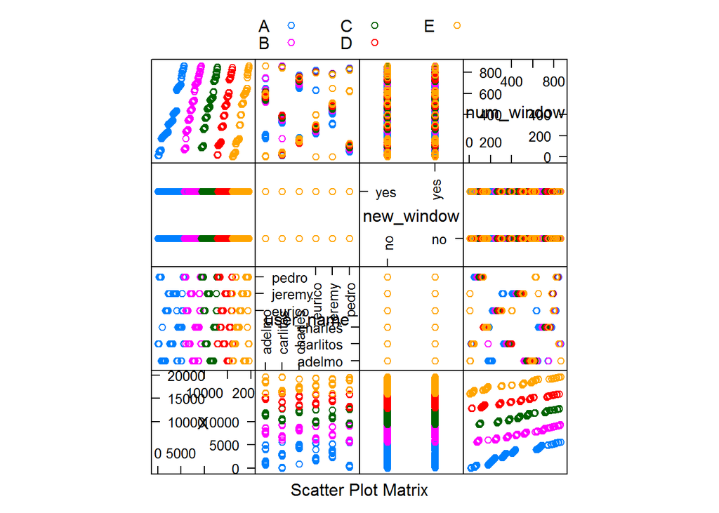

```r
library(caret)
pmlTraining <- read.csv("pml-training.csv", na.strings=c("#DIV/0!","NA"))
pmlTesting <- read.csv("pml-testing.csv", na.strings=c("#DIV/0!","NA"))
featurePlot(x=pmlTraining[,c("X", "user_name", "new_window", "num_window")], y=pmlTraining$classe, plot="pairs", auto.key=list(columns=3))
```

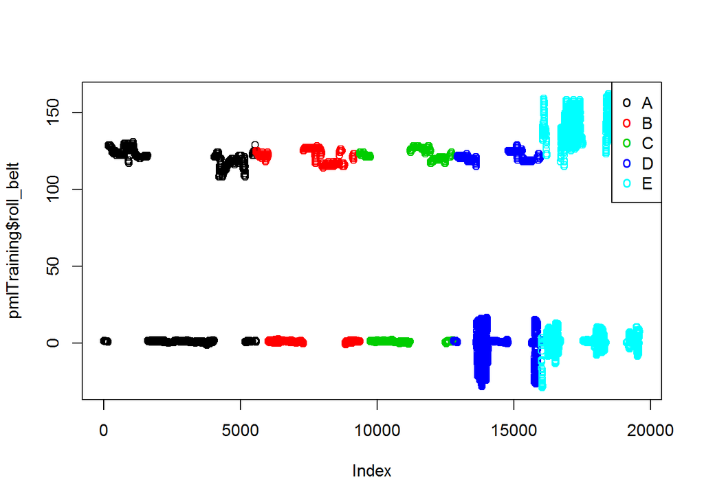

```r
plot(pmlTraining$roll_belt, col=pmlTraining$classe)
legend('topright', legend=levels(pmlTraining$classe), pch='o', col=1:5)
```

## Partition and clean the data

```r
keepCol <- sapply(pmlTesting, is.numeric)
keepCol[c(1:7)] = FALSE
inTrain <- createDataPartition(y=pmlTraining$class, p=0.6, list=FALSE)
training <- pmlTraining[inTrain, keepCol]
testing <- pmlTraining[-inTrain, keepCol]
submission <- pmlTesting[, keepCol]
nsvCol <- nearZeroVar(training, saveMetrics=TRUE)
```

## Set up environment to use multi-core

Using the doParallel package, parallel processing on multi-core is possible. This is necessary as training with the Random Forest method is computationally intensive.

```r
library(doParallel)
cluster <- makeCluster(max(detectCores() - 1), 1)
registerDoParallel(cluster)
train_control <- trainControl(allowParallel=TRUE)
```

## Train model with Random Forest method

```r
modFit <- train(classe ~ ., data=training, method="rf", trControl=train_control, prox=TRUE)
```

```r
varImp(modFit)
```

```
## rf variable importance
##
##   only 20 most important variables shown (out of 52)
##
##                      Overall
## roll_belt             100.00
## yaw_belt               77.39
## magnet_dumbbell_z      64.68
## pitch_forearm          60.74
## magnet_dumbbell_y      59.23
## pitch_belt             58.33
## magnet_dumbbell_x      52.19
## roll_forearm           48.14
## magnet_belt_y          46.47
## accel_belt_z           45.26
## accel_dumbbell_y       40.44
## roll_dumbbell          40.33
## magnet_belt_z          39.79
## accel_dumbbell_z       35.79
## roll_arm               35.53
## accel_forearm_x        33.09
## gyros_belt_z           28.86
## total_accel_dumbbell   27.89
## gyros_dumbbell_y       27.71
## yaw_dumbbell           27.32
```

The Variable Importance shows the relative importance of the 20 most important variables that were found through training using Random Forest method.

## Cross-validation and estimating out of sample error

```r
modFit
```

[output not shown]

```r
pred <- predict(modFit, testing)
confusionMatrix(pred, testing$classe)
```

```
## Confusion Matrix and Statistics
##
##           Reference
## Prediction    A    B    C    D    E
##          A 2229    8    0    0    0
##          B    3 1508   10    0    0
##          C    0    2 1351   10    0
##          D    0    0    7 1276    2
##          E    0    0    0    0 1440
##
## Overall Statistics
##
##                Accuracy : 0.9946
##                  95% CI : (0.9928, 0.9961)
##     No Information Rate : 0.2845
##     P-Value [Acc > NIR] : < 2.2e-16
##
##                   Kappa : 0.9932
##  Mcnemar's Test P-Value : NA
##
## Statistics by Class:
##
##                      Class: A Class: B Class: C Class: D Class: E
## Sensitivity            0.9987   0.9934   0.9876   0.9922   0.9986
## Specificity            0.9986   0.9979   0.9981   0.9986   1.0000
## Pos Pred Value         0.9964   0.9915   0.9912   0.9930   1.0000
## Neg Pred Value         0.9995   0.9984   0.9974   0.9985   0.9997
## Prevalence             0.2845   0.1935   0.1744   0.1639   0.1838
## Detection Rate         0.2841   0.1922   0.1722   0.1626   0.1835
## Detection Prevalence   0.2851   0.1939   0.1737   0.1638   0.1835
## Balanced Accuracy      0.9986   0.9957   0.9929   0.9954   0.9993
```

The default settings of caret package were used for training, which automatically performs cross-validation.  
In this case resampling method was Cross-Validated, 10 fold, repeated 3 times.  
The fitted model output estimates an accuracy of 0.9905460, ie. error = 0.9454%  
This is cross-checked using the testing partition, giving an accuracy of 0.9946, ie. output of sample error = 0.54%

## Prediction for submission

```r
pred_submission <- predict(modFit, submission)

pml_write_files = function(x){
    n = length(x)
    for(i in 1:n){
        filename = paste0("problem_id_",i,".txt")
        write.table(x[i],file=filename,quote=FALSE,row.names=FALSE,col.names=FALSE)
    }
}
pml_write_files(pred_submission)
```